# Tarea 4: Procesamiento de Flujos

Alejandra Lelo de Larrea Ibarra

24/02/2019

# Filtro de Bloom (diccionario)

## Datos del diccionario

```r
# Librerias
library(tidyverse)
# Leemos las palabras en el diccionario (Español)
diccionario <- read_csv("../datos/diccionario/es_dic.txt", col_names = FALSE) %>%
          pluck("X1")
# nota: el encoding del diccionario debe ser utf-8
# diccionario <- iconv(diccionario, to = "UTF-8")

# No de palabras en el diccionario.
m <- length(diccionario)
m
```

```
## [1] 247049
```

# Parámetros

```r
# no de bits
n <- 8e6

# Tamaño del conjunto a insertar
s = 300000

# No de funciones hash.
k=6


# Calculo de falsos positivos
tasa_fp <- function(n, s, k) {
    (1 - (1 - (1 / n)) ^ (k * s)) ^ k
}

# proba de falsos positivos
tasa_fp(n,s,k)
```

```
## [1] 6.690225e-05
```

## Funciones hash

```r
# Carga librerías
library(digest)

# Fija la semilla
set.seed(18823)

# Genera las k funciones hash con modulo n.
hash_generator <- function(k = 1, n){

  # Fija las semillas.
  seeds <- sample.int(652346, k)

  # Función hash final.
  hasher <- function(x){

    # Extrae la semillas
    sapply(seeds, function(s){
      # en digest, serialize puede ser false, pues trabajamos con cadenas
      # la salida de xxhash32 son 8 caracteres hexadecimales, pero
      # solo tomamos 7 para poder convertir a un entero
      sub_str <- substr(digest::digest(tolower(x), "xxhash32",
                                       serialize = FALSE, seed = s), 1, 7)

      # convierte a base hexadecimal y luego modulo n
      strtoi(sub_str, base = 16L) %% n + 1
    })
  }
  hasher
}
```

## Filtro de Bloom

```r
filtro_bloom <- function(num_hashes, n){

    # representación del vector de bits
    v <- raw(n)

    # Genera las funciones hash modulo n
    hashes <- hash_generator(num_hashes, n)

    # Insertar palabras del diccionario
    insertar <- function(x){
        x <- iconv(x, "utf-8")

        # Nota: esta v es la v del ambiente anterior, lleva la doble flecha para
        # decirle a R que busque en el ambiente anterior a esta función.
        # Si pongo la flecha simple va a arrojar un error porque no existe un v en esta función.
        v[hashes(x)] <<- as.raw(1)
    }

    # Función para checar si está en filtro.
    en_filtro <- function(x){

        # Revisa si las posiciones de los hashes dados son todas iguales a uno.
        all(as.logical(v[hashes(x)]))
    }

    # Función para devolver el vector v.
    vec <- function() v

    # Retorno de la función. Notar que todas las salidas refieren al mismo vector v. Cuando acutalizo un valor, se actualiza para todas las salidas.
    filtro <- list(insertar = insertar, en_filtro = en_filtro, vec = vec)

    # Retorno
    filtro
}
```

## Sugerencias de corrección de ortografía

```r
# Busca palabras cercanas haciendo eliminaciones, sustituciones, transposiciones o inserciones.
generar_dist_1 <- function(palabra){

  caracteres <- c(letters, 'á', 'é', 'í', 'ó', 'ú', 'ñ')

  # Parte el string en dos partes tomando cada posicion como separador en cada elemento del vector.
  # Ejem: para la palabra casa tenemos: "" - casa, c-asa, ca-sa, cas-a, casa-""
  pares <- lapply(0:(nchar(palabra)), function(i){
    c(str_sub(palabra, 1, i), str_sub(palabra, i+1, nchar(palabra)))
  })

  # palabras obtenidas al eliminar una letra.
  eliminaciones <- pares %>% map(function(x){ paste0(x[1], str_sub(x[2],2,-1))})

  # Palabras obtenidas de sustituir una letra por otra del diccionario
  # (en cada posición) incluyendo acetos y la ñ.
  sustituciones <- pares %>% map(function(x)
      map(caracteres, function(car){
    paste0(x[1], car, str_sub(x[2], 2 ,-1))
  })) %>% flatten

  # Palabras obtenidas de agregar una letra del diccionario en cada
  # posición incluyendo acentos y la ñ
  inserciones <- pares %>% map(function(x){
    map(caracteres, function(car) paste0(x[1], car, x[2]))
  }) %>% flatten

  # Palabras obtenidas de intercambiar dos letras consecutivas
  transposiciones <- pares %>% map(function(x){
    paste0(x[1], str_sub(x[2],2,2), str_sub(x[2],1,1), str_sub(x[2],3,-1))
  })

  # Junta todas las posibles palabras.
  c(eliminaciones, sustituciones, transposiciones, inserciones) %>% unlist
}
```

## Correr filtro

```r
# Fija la semilla
set.seed(812)

# Crea el filtro de bloom con 6 hashes y 8 millones de bits.
filtro_b <- filtro_bloom(num_hashes = k, n = n)

# insertar palabras de diccionario
system.time(
    for(i in seq_along(diccionario)){
        filtro_b$insertar(diccionario[i])
    })
```

```
##    user  system elapsed
##  95.420   0.030  95.476
```

## Buscar palabras que no estén en el diccionario

Encuentra alguna palabra del español que no esté en el filtro.

```r
palabras_faltantes<-c("mixote",
                      "chocolate",
                      "Chapulin",
                      "mixteco",
                      "churro")

df_faltantes<-tibble(palabra=palabras_faltantes)%>%
  mutate(En_Diccionario=map_lgl(palabra,filtro_b$en_filtro))

df_faltantes
```

```
## # A tibble: 5 x 2
##   palabra   En_Diccionario
##   <chr>     <lgl>
## 1 mixote    FALSE
## 2 chocolate TRUE
## 3 Chapulin  FALSE
## 4 mixteco   FALSE
## 5 churro    TRUE
```

Agrégala al filtro y verifica que es detectada como positiva.

```r
# Nos quedamos con las palabras que no están en el filtro.
df_faltantes<-filter(df_faltantes,En_Diccionario==FALSE)

# Las agergamos al filtro
aux<-lapply(df_faltantes$palabra,filtro_b$insertar)

# Verificamos que esten detectadas como positivas
df_faltantes<-df_faltantes %>%
  mutate(En_Diccionario=map_lgl(palabra,filtro_b$en_filtro))

df_faltantes
```

```
## # A tibble: 3 x 2
##   palabra  En_Diccionario
##   <chr>    <lgl>
## 1 mixote   TRUE
## 2 Chapulin TRUE
## 3 mixteco  TRUE
```

Busca una manera incorrecta de escribirla y prueba la función de sugerencias.

```r
# Forma incorrecta de escribir las palabras
incorrectas<-c("mizote","capulin","mitxeco")

# Función para aplicar el corrector de ortografía
corrector<-function(x) generar_dist_1(x)%>%keep(filtro_b$en_filtro)

lapply(incorrectas,corrector)
```

```
## [[1]]
## [1] "mixote"
##
## [[2]]
## [1] "chapulin"
##
## [[3]]
## [1] "mixteco"
```

## Menos bits

### Parámetros

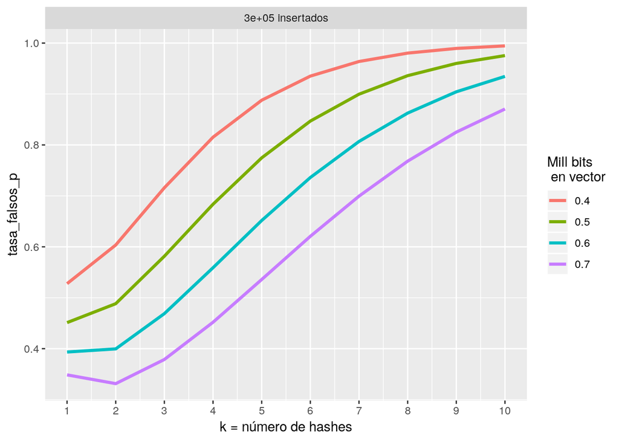

```r
df <- expand.grid(list(s = 300000, # valores a insertar
                  k = 1:10, # no. funciones hash
                  n = c(0.4e6,0.5e6,0.6e6,0.7e6) # no bits.
                  )) %>%
      mutate(millones_bits = (n/1e6)) %>% # convierte a millones
      mutate(tasa_falsos_p = tasa_fp(n, s, k)) %>% # calcula proba de falsos pos.
      mutate(s_str = paste0(s, ' insertados'))


# Grafica de análisis de filtro de bloom
ggplot(df, aes(x = k, y = tasa_falsos_p,
               colour=factor(millones_bits), group=millones_bits)) +
               geom_line(size=1.2) +
               facet_wrap(~s_str) +
               labs(x="k = número de hashes",
                    colour = "Mill bits \n en vector") +
               scale_x_continuous(breaks=1:10,labels=1:10)
```

```r
               scale_y_log10(breaks= c(0.0001, 0.001, 0.01, 0.1))
```

```
## <ScaleContinuousPosition>
##  Range:
##  Limits:    0 --    1
```

```r
# no de bits
n <- 5e5

# Tamaño del conjunto a insertar
s = 300000

# No de funciones hash.
k=1


# Calculo de falsos positivos
tasa_fp <- function(n, s, k) {
    (1 - (1 - (1 / n)) ^ (k * s)) ^ k
}

# proba de falsos positivos
tasa_fp(n,s,k)
```

```
## [1] 0.4511887
```

## Correr filtro

```r
# Fija la semilla
set.seed(812)

# Crea el filtro de bloom con 6 hashes y 8 millones de bits.
filtro_b <- filtro_bloom(num_hashes = k, n = n)

# insertar palabras de diccionario
system.time(
    for(i in seq_along(diccionario)){
        filtro_b$insertar(diccionario[i])
    })
```

```
##    user  system elapsed
##  21.690   0.010  21.726
```

## Buscar palabras que no estén en el diccionario

Encuentra alguna palabra del español que no esté en el filtro.

```r
palabras_faltantes<-c("mixote",
                      "chocolate",
                      "Chapulin",
                      "mixteco",
                      "churro")

df_faltantes<-tibble(palabra=palabras_faltantes)%>%
  mutate(En_Diccionario=map_lgl(palabra,filtro_b$en_filtro))

df_faltantes
```

```
## # A tibble: 5 x 2
##   palabra   En_Diccionario
##   <chr>     <lgl>
## 1 mixote    FALSE
## 2 chocolate TRUE
## 3 Chapulin  TRUE
## 4 mixteco   TRUE
## 5 churro    TRUE
```

Agrégala al filtro y verifica que es detectada como positiva.

```r
# Nos quedamos con las palabras que no están en el filtro.
df_faltantes<-filter(df_faltantes,En_Diccionario==FALSE)

# Las agergamos al filtro
aux<-lapply(df_faltantes$palabra,filtro_b$insertar)

# Verificamos que esten detectadas como positivas
df_faltantes<-df_faltantes %>%
  mutate(En_Diccionario=map_lgl(palabra,filtro_b$en_filtro))

df_faltantes
```

```
## # A tibble: 1 x 2
##   palabra En_Diccionario
##   <chr>   <lgl>
## 1 mixote  TRUE
```

Busca una manera incorrecta de escribirla y prueba la función de sugerencias.

```r
# Forma incorrecta de escribir las palabras
incorrectas<-c("mizote","capulin","mitxeco")

# Función para aplicar el corrector de ortografía
corrector<-function(x) generar_dist_1(x)%>%keep(filtro_b$en_filtro)

lapply(incorrectas,corrector)
```

```
## [[1]]
##   [1] "izote"   "mizoe"   "aizote"  "bizote"  "cizote"  "dizote"  "hizote"
##   [8] "pizote"  "rizote"  "sizote"  "tizote"  "vizote"  "xizote"  "íizote"
##  [15] "óizote"  "mdzote"  "mezote"  "mgzote"  "mhzote"  "mjzote"  "mkzote"
##  [22] "mlzote"  "mmzote"  "mozote"  "mrzote"  "mszote"  "muzote"  "mwzote"
##  [29] "myzote"  "mñzote"  "mieote"  "mimote"  "minote"  "mioote"  "miqote"
##  [36] "misote"  "mitote"  "mixote"  "miíote"  "mizate"  "mizcte"  "mizete"
##  [43] "mizfte"  "mizkte"  "mizlte"  "mizmte"  "mizqte"  "mizrte"  "mizste"
##  [50] "mizute"  "mizzte"  "mizáte"  "mizóte"  "mizúte"  "mizoae"  "mizoce"
##  [57] "mizoee"  "mizofe"  "mizole"  "mizome"  "mizone"  "mizoqe"  "mizose"
##  [64] "mizove"  "mizoxe"  "mizoée"  "mizoíe"  "mizoúe"  "mizoñe"  "mizotb"
##  [71] "mizotc"  "mizotg"  "mizoti"  "mizotm"  "mizoto"  "mizotq"  "mizotr"
##  [78] "mizots"  "mizotv"  "mizoty"  "mizotí"  "mizotñ"  "mizotea" "mizotef"
##  [85] "mizoteg" "mizoteo" "mizotep" "mizotes" "mizoteu" "mizotew" "mizoteá"
##  [92] "mziote"  "mizoet"  "cmizote" "emizote" "gmizote" "hmizote" "imizote"
```

[output cut: 86 more lines]

# Muestra distribuida uniformemente en el flujo

Sea $k$ el tamaño de la muestra (fijo), sea $n_0$ el flujo histórico y sea $n$ el flujo completo al llegar una nueva observación (es decir $n=n_0+1$). Tomemos la observación $i$ del flujo:

- Si $i>n_0$ es la nueva observación y entonces se selecciona para ser parte de la muestra con probabilidad $k/n$.
- Si $i\leq n_0$ tengo dos opciones:
  - Que se agregue la nueva observción (con probabilidad $k/n$. En este caso, para que la observación $i$ esté en la muestra tuvo que haber sido seleccionada en el paso anterior (probabilidad $k/n_0$) y que no sea seleccionado para se reemplazado por la nueva observación (probabilidad $k-1/k$).
  - Que no se agregue la nueva observacvión (con probabilidad $1-k/n$) y que la observación $i$ esté en la muestra desde el paso anterior (probabilidad $k/n_0$)

De esta manera, para la observación $i$:

$$\begin{eqnarray*}
p(i en muestra)&=&\left(1-\dfrac{k}{n}\right)\left(\dfrac{k}{n_0}\right)+\left(\dfrac{k}{n}\right)\left(\dfrac{k-1}{k}\right)\left(\dfrac{k}{n_0}\right)\\
&=& \dfrac{(n-k)k}{nn_0}+\dfrac{(k-1)k}{nn_0}\\
&=& \dfrac{(n-k)k+(k-1)k}{nn_0}\\
&=& \dfrac{k(n-k+k-1)}{nn_0}\\
&=& \dfrac{k(n-1)}{nn_0}\\
&=& \dfrac{kn_0}{nn_0}\\
&=& \dfrac{k}{n}
\end{eqnarray*}$$

Por lo tanto, $\forall i=1,2, \cdots, n$. Por lo tanto, la probabilidad es uniforme $k/n$.

# Combinación de estimadores hyperloglog

```r
# Función hash para cadenas
hash_gen <- function(seed){

  # Función hash para la semilla específica
  function(x){

    # Genera una función hash con el algoritmo xxhash32 (strings de tamaño 8)
    hash_32 <- digest::digest(x, 'xxhash32', serialize = FALSE, seed = seed)

    # Covertimos a bits, tomando de dos en dos:
    # Esta implementación es lenta
    sapply(seq(1, nchar(hash_32), 2), function(x) substr(hash_32, x, x+1)) %>% # toma 2 caracteres
        strtoi(16L) %>% # convierte strings a entero de acuerdo con la base dada
      as.raw %>% rawToBits()
  }
}

# Fija la semilla
set.seed(5451)

# Genera las funciones hash
hash_1 <- hash_gen(seed = 123)
hash_2 <- hash_gen(seed = 564)


# Tamaño de cola ceros al eliminar los primeros bits.
tail_length_lead <- function(bits){
  bits[-c(1:cubeta_bits)] %>% which.max %>% as.integer
}


# Calcula la cubeta con los primeros bits
cubeta <- function(bits){
  paste0(as.character(bits[1:cubeta_bits]), collapse = "")
}

# No. elems distintos (100 mil)
n <- 250000

# Se fija el no de bits para construir las cubetas
cubeta_bits <- 5

# Se calcula m
m <- 2^cubeta_bits

# Datos simulados
df <- data_frame(num_distintos = 1:n) %>% # elems distintos
      mutate(id = as.character(sample.int(52345678, n, replace = FALSE))) %>% # muestreo de datos sin reemplazo
      mutate(hash = map(id, hash_1)) %>% # aplica fn hash 1
      mutate(cubeta = map_chr(hash, cubeta)) # Calcula cubeta
df
```

```
## # A tibble: 250,000 x 4
##    num_distintos id       hash       cubeta
##            <int> <chr>    <list>     <chr>
##  1             1 12638327 <raw [32]> 0000000000
##  2             2 32768794 <raw [32]> 0001010101
##  3             3 35769702 <raw [32]> 0100000000
##  4             4 49696296 <raw [32]> 0000000101
##  5             5 25500838 <raw [32]> 0001000001
##  6             6 21102554 <raw [32]> 0000010000
##  7             7 23517787 <raw [32]> 0000010100
##  8             8 46271047 <raw [32]> 0000010100
##  9             9 23945948 <raw [32]> 0000000100
## 10            10 25704509 <raw [32]> 0001010101
## # ... with 249,990 more rows
```

```r
# Longitud de la cola sin los primeros bits
df <- df %>% mutate(tail = map_int(hash, tail_length_lead))
df
```

```
## # A tibble: 250,000 x 5
##    num_distintos id       hash       cubeta      tail
##            <int> <chr>    <list>     <chr>      <int>
##  1             1 12638327 <raw [32]> 0000000000     1
##  2             2 32768794 <raw [32]> 0001010101     2
##  3             3 35769702 <raw [32]> 0100000000     2
##  4             4 49696296 <raw [32]> 0000000101     2
##  5             5 25500838 <raw [32]> 0001000001     6
##  6             6 21102554 <raw [32]> 0000010000     1
##  7             7 23517787 <raw [32]> 0000010100     1
##  8             8 46271047 <raw [32]> 0000010100     1
##  9             9 23945948 <raw [32]> 0000000100     3
## 10            10 25704509 <raw [32]> 0001010101     2
## # ... with 249,990 more rows
```

```r
# Para 50mil elementos distintos
resumen<- df %>% # datos
  filter(num_distintos <= n) %>% # filtra obs
    group_by(cubeta) %>% # agrupa por cubeta
    summarise(tail_max = max(tail)) # obtiene el max de la cola

# Resumen
resumen
```

```
## # A tibble: 32 x 2
##    cubeta     tail_max
##    <chr>         <dbl>
##  1 0000000000       12
##  2 0000000001       14
##  3 0000000100       12
##  4 0000000101       13
##  5 0000010000       14
##  6 0000010001       13
##  7 0000010100       13
##  8 0000010101       13
##  9 0001000000       16
## 10 0001000001       12
## # ... with 22 more rows
```

```r
# Función para calcular la media armónica
armonica <- function(x) 1/mean(1/x)

# Media armónica reescalada para
0.72 * m * armonica(2 ^ resumen$tail_max)
```

```
## [1] 260344.9
```

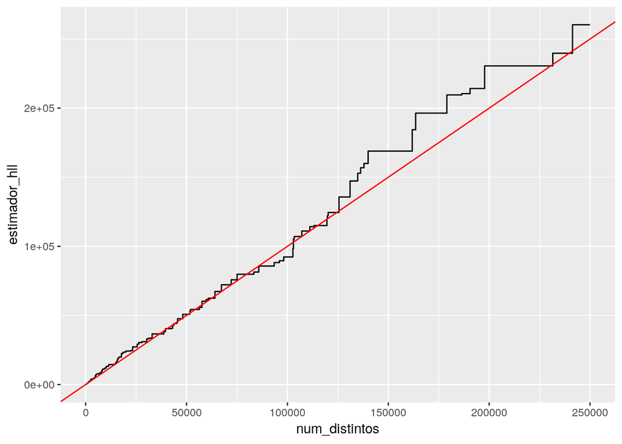

```r
# Copleta las posibles combinaciones de cubeta y tamaño de cola
res <- df %>% spread(cubeta, tail, fill = 0) %>% # convierte a wide por cubeta llenando el tamaño de cola maxima.
        gather(cubeta, tail, -num_distintos, -id, -hash) %>% # conviertea long eliminando distintos, id y hash
        select(num_distintos, cubeta, tail)  # selecciona columnas

# Agrupar por cubeta
res_2 <- res %>%
      group_by(cubeta) %>% # agrupa por cubeta
      arrange(num_distintos) %>% # ordena por num_distintos
      mutate(tail_max = cummax(tail)) %>% # maximo acumulado
      group_by(num_distintos) %>% # agrupa por num_distintos
      summarise(estimador_hll = 0.72*(m*armonica(2^tail_max))) # estima no distintos.


# grafica estimadores en cada momento
ggplot(res_2 %>% filter(num_distintos > 100),
       aes(x = num_distintos, y = estimador_hll)) + geom_line() +
  geom_abline(slope = 1, colour ='red')
```

```r
# Calculo de cuantiles del error
quantile(1 - res_2$estimador_hll/res_2$num_distintos, probs=c(0.1, 0.5, .9))
```

```
##         10%         50%         90%
## -0.16345915 -0.05598914  0.02599921
```